## Understanding the loan data

# Propser Data Exploration

## by Raj Palavarapu

> This notebook analyzes the loan data from Prosper.This data set contains 113,937 loans with 81 variables for each loan that has been issued.We will be analyzing the various factors that are affecting the loan status and vizualize the relationship between various variables.

Variables that are used in the analysis BorrowerAPR: The Borrower's Annual Percentage Rate (APR) for the loan.

CreditGrade: The Credit rating that was assigned at the time the listing went live. Applicable for listings pre-2009 period and will only be populated for those listings.

OnTimeProsperPayments : Number of on time payments the borrower had made on Prosper loans at the time they created this listing. This value will be null if the borrower has no prior loans.

IncomeRange : The income range of the borrower at the time the listing was created.

StatedMonthlyIncome : The monthly income the borrower stated at the time the listing was created.

LoanOriginalAmount:The origination amount of the loan.

ProsperRating (Alpha):The Prosper Rating assigned at the time the listing was created between AA - HR. Applicable for loans originated after July 2009.

DebtToIncomeRatio:The debt to income ratio of the borrower at the time the credit profile was pulled. This value is Null if the debt to income ratio is not available. This value is capped at 10.01 (any debt to income ratio larger than 1000% will be returned as 1001%).

LoanStatus:The current status of the loan: Cancelled, Chargedoff, Completed, Current, Defaulted, FinalPaymentInProgress, PastDue. The PastDue status will be accompanied by a delinquency bucket.

CreditGrade:The Credit rating that was assigned at the time the listing went live. Applicable for listings pre-2009 period and will only be populated for those listings.

EstimatedLoss:Estimated loss is the estimated principal loss on charge-offs. Applicable for loans originated after July 2009.

OnTimeProsperPayments:Number of on time payments the borrower had made on Prosper loans at the time they created this listing. This value will be null if the borrower has no prior loans.

```python
# import all packages and set plots to be embedded inline
import numpy as np
import pandas as pd
import matplotlib.pyplot as plt
import seaborn as sb
from IPython.display import display
%matplotlib inline
```

#### loading the data

```python
loan_data=pd.read_csv('data/prosperLoanData.csv')
display(loan_data.columns)
display(loan_data.info())
```

```
Index(['ListingKey', 'ListingNumber', 'ListingCreationDate', 'CreditGrade',
       'Term', 'LoanStatus', 'ClosedDate', 'BorrowerAPR', 'BorrowerRate',
       'LenderYield', 'EstimatedEffectiveYield', 'EstimatedLoss',
       'EstimatedReturn', 'ProsperRating (numeric)', 'ProsperRating (Alpha)',
       'ProsperScore', 'ListingCategory (numeric)', 'BorrowerState',
       'Occupation', 'EmploymentStatus', 'EmploymentStatusDuration',
       'IsBorrowerHomeowner', 'CurrentlyInGroup', 'GroupKey',
       'DateCreditPulled', 'CreditScoreRangeLower', 'CreditScoreRangeUpper',
       'FirstRecordedCreditLine', 'CurrentCreditLines', 'OpenCreditLines',
       'TotalCreditLinespast7years', 'OpenRevolvingAccounts',
       'OpenRevolvingMonthlyPayment', 'InquiriesLast6Months', 'TotalInquiries',
       'CurrentDelinquencies', 'AmountDelinquent', 'DelinquenciesLast7Years',
       'PublicRecordsLast10Years', 'PublicRecordsLast12Months',
       'RevolvingCreditBalance', 'BankcardUtilization',
       'AvailableBankcardCredit', 'TotalTrades',
       'TradesNeverDelinquent (percentage)', 'TradesOpenedLast6Months',
       'DebtToIncomeRatio', 'IncomeRange', 'IncomeVerifiable',
       'StatedMonthlyIncome', 'LoanKey', 'TotalProsperLoans',
       'TotalProsperPaymentsBilled', 'OnTimeProsperPayments',
       'ProsperPaymentsLessThanOneMonthLate',
       'ProsperPaymentsOneMonthPlusLate', 'ProsperPrincipalBorrowed',
       'ProsperPrincipalOutstanding', 'ScorexChangeAtTimeOfListing',
       'LoanCurrentDaysDelinquent', 'LoanFirstDefaultedCycleNumber',
       'LoanMonthsSinceOrigination', 'LoanNumber', 'LoanOriginalAmount',
       'LoanOriginationDate', 'LoanOriginationQuarter', 'MemberKey',
       'MonthlyLoanPayment', 'LP_CustomerPayments',
       'LP_CustomerPrincipalPayments', 'LP_InterestandFees', 'LP_ServiceFees',
       'LP_CollectionFees', 'LP_GrossPrincipalLoss', 'LP_NetPrincipalLoss',
       'LP_NonPrincipalRecoverypayments', 'PercentFunded', 'Recommendations',
       'InvestmentFromFriendsCount', 'InvestmentFromFriendsAmount',
       'Investors'],
      dtype='object')
```

```
<class 'pandas.core.frame.DataFrame'>
RangeIndex: 113937 entries, 0 to 113936
Data columns (total 81 columns):
ListingKey                             113937 non-null object
ListingNumber                          113937 non-null int64
ListingCreationDate                    113937 non-null object
CreditGrade                            28953 non-null object
Term                                   113937 non-null int64
LoanStatus                             113937 non-null object
ClosedDate                             55089 non-null object
BorrowerAPR                            113912 non-null float64
BorrowerRate                           113937 non-null float64
LenderYield                            113937 non-null float64
EstimatedEffectiveYield                84853 non-null float64
EstimatedLoss                          84853 non-null float64
EstimatedReturn                        84853 non-null float64
ProsperRating (numeric)                84853 non-null float64
ProsperRating (Alpha)                  84853 non-null object
ProsperScore                           84853 non-null float64
ListingCategory (numeric)              113937 non-null int64
BorrowerState                          108422 non-null object
Occupation                             110349 non-null object
EmploymentStatus                       111682 non-null object
EmploymentStatusDuration               106312 non-null float64
IsBorrowerHomeowner                    113937 non-null bool
CurrentlyInGroup                       113937 non-null bool
GroupKey                               13341 non-null object
DateCreditPulled                       113937 non-null object
CreditScoreRangeLower                  113346 non-null float64
CreditScoreRangeUpper                  113346 non-null float64
FirstRecordedCreditLine                113240 non-null object
CurrentCreditLines                     106333 non-null float64
OpenCreditLines                        106333 non-null float64
TotalCreditLinespast7years             113240 non-null float64
OpenRevolvingAccounts                  113937 non-null int64
OpenRevolvingMonthlyPayment            113937 non-null int64
InquiriesLast6Months                   113240 non-null float64
TotalInquiries                         112778 non-null float64
CurrentDelinquencies                   113240 non-null float64
AmountDelinquent                       106315 non-null float64
```

[output cut: 31 more lines]

```
LP_CustomerPayments                    113937 non-null float64
LP_CustomerPrincipalPayments           113937 non-null float64
LP_InterestandFees                     113937 non-null float64
LP_ServiceFees                         113937 non-null float64
LP_CollectionFees                      113937 non-null float64
LP_GrossPrincipalLoss                  113937 non-null float64
LP_NetPrincipalLoss                    113937 non-null float64
LP_NonPrincipalRecoverypayments        113937 non-null float64
PercentFunded                          113937 non-null float64
Recommendations                        113937 non-null int64
InvestmentFromFriendsCount             113937 non-null int64
InvestmentFromFriendsAmount            113937 non-null float64
Investors                              113937 non-null int64
dtypes: bool(3), float64(49), int64(12), object(17)
memory usage: 68.1+ MB
```

```
None
```

```python
loan_data.head()
```

|  | ListingKey | ListingNumber | ListingCreationDate | CreditGrade | Term | LoanStatus | ClosedDate | BorrowerAPR | BorrowerRate | LenderYield | ... | LP_ServiceFees | LP_CollectionFees | LP_GrossPrincipalLoss | LP_NetPrincipalLoss | LP_NonPrincipalRecoverypayments | PercentFunded | Recommendations | InvestmentFromFriendsCount | InvestmentFromFriendsAmount | Investors |
| --- | --- | --- | --- | --- | --- | --- | --- | --- | --- | --- | --- | --- | --- | --- | --- | --- | --- | --- | --- | --- | --- |
| 0 | 1021339766868145413AB3B | 193129 | 09:29.3 | C | 36 | Completed | 8/14/2009 0:00 | 0.16516 | 0.1580 | 0.1380 | ... | -133.18 | 0.0 | 0.0 | 0.0 | 0.0 | 1.0 | 0 | 0 | 0.0 | 258 |
| 1 | 10273602499503308B223C1 | 1209647 | 28:07.9 | NaN | 36 | Current | NaN | 0.12016 | 0.0920 | 0.0820 | ... | 0.00 | 0.0 | 0.0 | 0.0 | 0.0 | 1.0 | 0 | 0 | 0.0 | 1 |
| 2 | 0EE9337825851032864889A | 81716 | 00:47.1 | HR | 36 | Completed | 12/17/2009 0:00 | 0.28269 | 0.2750 | 0.2400 | ... | -24.20 | 0.0 | 0.0 | 0.0 | 0.0 | 1.0 | 0 | 0 | 0.0 | 41 |
| 3 | 0EF5356002482715299901A | 658116 | 02:35.0 | NaN | 36 | Current | NaN | 0.12528 | 0.0974 | 0.0874 | ... | -108.01 | 0.0 | 0.0 | 0.0 | 0.0 | 1.0 | 0 | 0 | 0.0 | 158 |
| 4 | 0F023589499656230C5E3E2 | 909464 | 38:39.1 | NaN | 36 | Current | NaN | 0.24614 | 0.2085 | 0.1985 | ... | -60.27 | 0.0 | 0.0 | 0.0 | 0.0 | 1.0 | 0 | 0 | 0.0 | 20 |

5 rows × 81 columns

```python
loan_data.shape
```

```
(113937, 81)
```

## Univariate Exploration

> In this section, investigate distributions of individual variables. If you see unusual points or outliers, take a deeper look to clean things up and prepare yourself to look at relationships between variables.

```python
loan_data.columns
```

```
Index(['ListingKey', 'ListingNumber', 'ListingCreationDate', 'CreditGrade',
       'Term', 'LoanStatus', 'ClosedDate', 'BorrowerAPR', 'BorrowerRate',
       'LenderYield', 'EstimatedEffectiveYield', 'EstimatedLoss',
       'EstimatedReturn', 'ProsperRating (numeric)', 'ProsperRating (Alpha)',
       'ProsperScore', 'ListingCategory (numeric)', 'BorrowerState',
       'Occupation', 'EmploymentStatus', 'EmploymentStatusDuration',
       'IsBorrowerHomeowner', 'CurrentlyInGroup', 'GroupKey',
       'DateCreditPulled', 'CreditScoreRangeLower', 'CreditScoreRangeUpper',
       'FirstRecordedCreditLine', 'CurrentCreditLines', 'OpenCreditLines',
       'TotalCreditLinespast7years', 'OpenRevolvingAccounts',
       'OpenRevolvingMonthlyPayment', 'InquiriesLast6Months', 'TotalInquiries',
       'CurrentDelinquencies', 'AmountDelinquent', 'DelinquenciesLast7Years',
       'PublicRecordsLast10Years', 'PublicRecordsLast12Months',
       'RevolvingCreditBalance', 'BankcardUtilization',
       'AvailableBankcardCredit', 'TotalTrades',
       'TradesNeverDelinquent (percentage)', 'TradesOpenedLast6Months',
       'DebtToIncomeRatio', 'IncomeRange', 'IncomeVerifiable',
       'StatedMonthlyIncome', 'LoanKey', 'TotalProsperLoans',
       'TotalProsperPaymentsBilled', 'OnTimeProsperPayments',
       'ProsperPaymentsLessThanOneMonthLate',
       'ProsperPaymentsOneMonthPlusLate', 'ProsperPrincipalBorrowed',
       'ProsperPrincipalOutstanding', 'ScorexChangeAtTimeOfListing',
       'LoanCurrentDaysDelinquent', 'LoanFirstDefaultedCycleNumber',
       'LoanMonthsSinceOrigination', 'LoanNumber', 'LoanOriginalAmount',
       'LoanOriginationDate', 'LoanOriginationQuarter', 'MemberKey',
       'MonthlyLoanPayment', 'LP_CustomerPayments',
       'LP_CustomerPrincipalPayments', 'LP_InterestandFees', 'LP_ServiceFees',
       'LP_CollectionFees', 'LP_GrossPrincipalLoss', 'LP_NetPrincipalLoss',
       'LP_NonPrincipalRecoverypayments', 'PercentFunded', 'Recommendations',
       'InvestmentFromFriendsCount', 'InvestmentFromFriendsAmount',
       'Investors'],
      dtype='object')
```

```python
loan_data['BorrowerAPR'].describe()
```

```
count    113912.000000
mean          0.218828
std           0.080364
min           0.006530
25%           0.156290
50%           0.209760
75%           0.283810
max           0.512290
Name: BorrowerAPR, dtype: float64
```

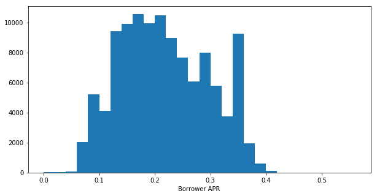

```python
bins = np.arange(0, loan_data['BorrowerAPR'].max()+0.05, 0.02)
plt.figure(figsize=[10, 5])
plt.hist(data = loan_data, x = 'BorrowerAPR', bins = bins);
plt.xlabel('Borrower APR');
```

```python
loan_data['LoanOriginalAmount'].describe()
```

```
count    113937.00000
mean       8337.01385
std        6245.80058
min        1000.00000
25%        4000.00000
50%        6500.00000
75%       12000.00000
max       35000.00000
Name: LoanOriginalAmount, dtype: float64
```

> Distrubution of propser ratings

```python
loan_data['ProsperRating (Alpha)'].value_counts()
```

```
C     18345
B     15581
A     14551
D     14274
E      9795
HR     6935
AA     5372
Name: ProsperRating (Alpha), dtype: int64
```

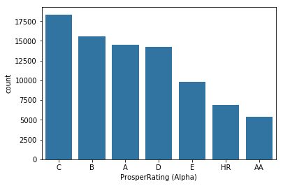

```python
order=loan_data['ProsperRating (Alpha)'].value_counts().index
base_color = sb.color_palette()[0]
sb.countplot(data = loan_data, x = 'ProsperRating (Alpha)', color = base_color,order=order)
```

> Distribution of credit Grade

```python
loan_data['CreditGrade'].value_counts()
```

```
C     5649
D     5153
B     4389
AA    3509
HR    3508
A     3315
E     3289
NC     141
Name: CreditGrade, dtype: int64
```

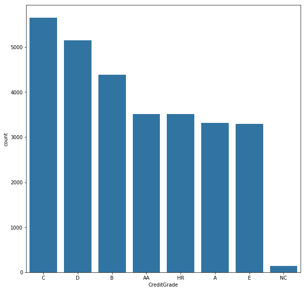

```python
order=loan_data['CreditGrade'].value_counts().index
plt.figure(figsize=[10,10])
base_color = sb.color_palette()[0]
sb.countplot(data = loan_data, x = 'CreditGrade', color = base_color,order=order)
```

> Distribution of debt to income ratio

```python
loan_data['DebtToIncomeRatio'].describe()
```

```
count    105383.000000
mean          0.275947
std           0.551759
min           0.000000
25%           0.140000
50%           0.220000
75%           0.320000
max          10.010000
Name: DebtToIncomeRatio, dtype: float64
```

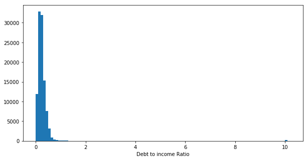

```python
bins = np.arange(0,loan_data['DebtToIncomeRatio'].max()+0.2,0.1)
plt.figure(figsize=[10, 5])
plt.hist(data = loan_data, x = 'DebtToIncomeRatio', bins = bins);
plt.xlabel('Debt to income Ratio');
```

> Distribution of Borrower's income

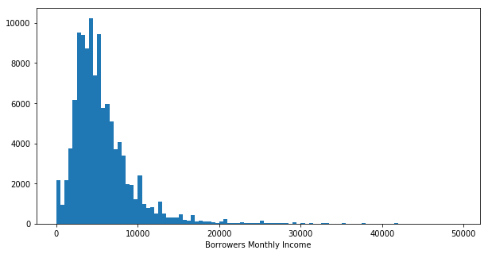

```python
bins = np.arange(0,50000,500)
plt.figure(figsize=[10, 5])
plt.hist(data = loan_data, x = 'StatedMonthlyIncome', bins = bins);
plt.xlabel('Borrowers Monthly Income');
```

```python
#The distribution of borrowers monthly income looks right skewed, percent of borrowers whose  monthly income greater than 35k
```

```python
pct=(loan_data['StatedMonthlyIncome']>35000).sum()/float(loan_data.shape[0])
pct
```

```
0.0018167934911398405
```

Less than 0.2 percent borrowers have stated monthly income greater than 35k and this looks like an outlier

> Distribution of Loan status

```python
loan_data['LoanStatus'].value_counts()
```

```
Current                   56576
Completed                 38074
Chargedoff                11992
Defaulted                  5018
Past Due (1-15 days)        806
Past Due (31-60 days)       363
Past Due (61-90 days)       313
Past Due (91-120 days)      304
Past Due (16-30 days)       265
FinalPaymentInProgress      205
Past Due (>120 days)         16
Cancelled                     5
Name: LoanStatus, dtype: int64
```

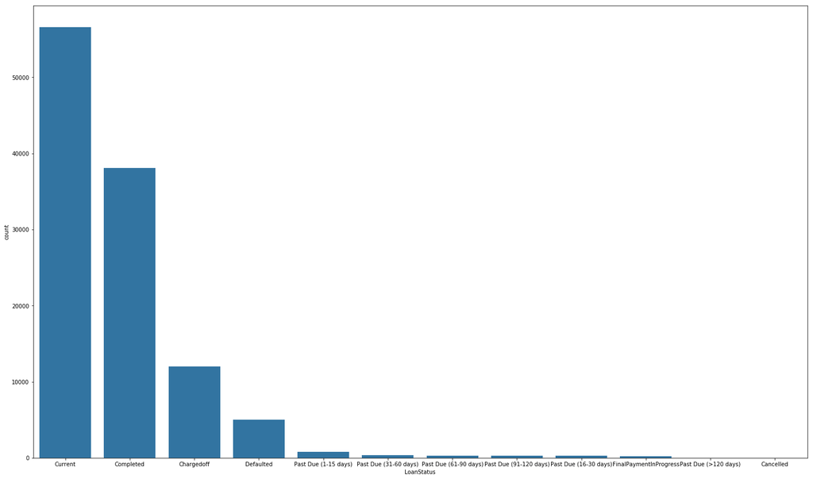

```python
order=loan_data['LoanStatus'].value_counts().index
plt.figure(figsize=[25,15])
base_color = sb.color_palette()[0]
sb.countplot(data = loan_data, x = 'LoanStatus', color = base_color,order=order)
```

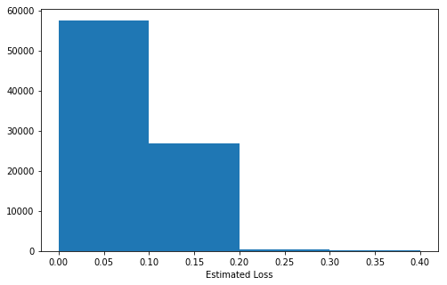

```python
bins = np.arange(0,loan_data['EstimatedLoss'].max()+0.1,0.1)
plt.figure(figsize=[8,5])
plt.hist(data = loan_data, x = 'EstimatedLoss', bins = bins);
plt.xlabel('Estimated Loss');
```

## Bivariate Exploration

> We will analyze the relationship between CreditGrade amd Borrower APR and see how creditGrade is affecting the APR

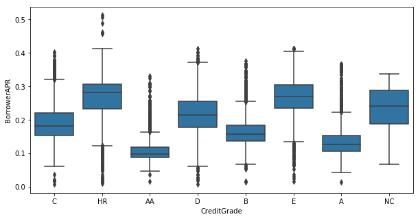

```python
plt.figure(figsize = [10, 5])
base_color = sb.color_palette()[0]
sb.boxplot(data = loan_data, x = 'CreditGrade', y = 'BorrowerAPR', color = base_color)
```

> We will analyze the relationship between CreditGrade amd LoanOriginalAmount and see how creditGrade is affecting the Loanamount

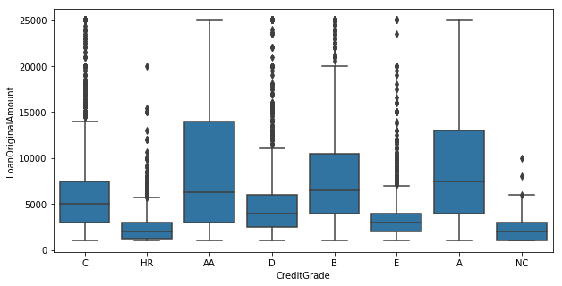

```python
plt.figure(figsize = [10, 5])
base_color = sb.color_palette()[0]
sb.boxplot(data = loan_data, x = 'CreditGrade', y = 'LoanOriginalAmount', color = base_color)
```

> We will analyze the relationship between ProsperRating amd BorrowerAPR and see how ProsperRating is affecting the BorrowerAPR

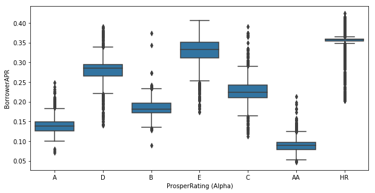

```python
plt.figure(figsize = [10, 5])
base_color = sb.color_palette()[0]
sb.boxplot(data = loan_data, x = 'ProsperRating (Alpha)', y = 'BorrowerAPR', color = base_color)
```

> We will analyze the relationship between ProsperRating amd OnTimeProsperPayments and see if highprosper rating is resulting in more onTime payments

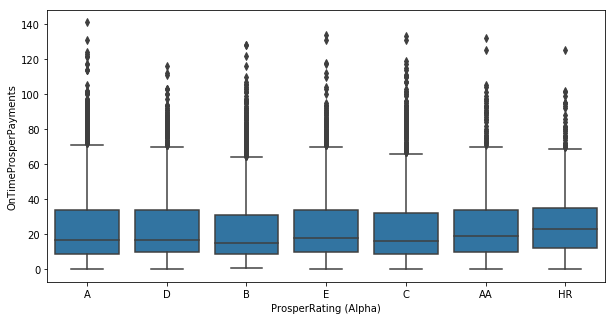

```python
plt.figure(figsize = [10, 5])
base_color = sb.color_palette()[0]
sb.boxplot(data = loan_data, x = 'ProsperRating (Alpha)', y = 'OnTimeProsperPayments', color = base_color)
```

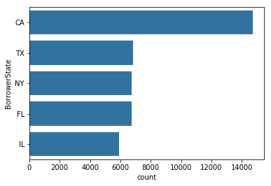

```python
base_color = sb.color_palette()[0]
ax=sb.countplot(y='BorrowerState',data=loan_data,color=base_color,order=loan_data['BorrowerState'].value_counts().iloc[:5].index)
```

## Multivariate Exploration

> In this Multivariate Exploration we are going to analyze the Propser Rating effect on relationship of APR and loan amount

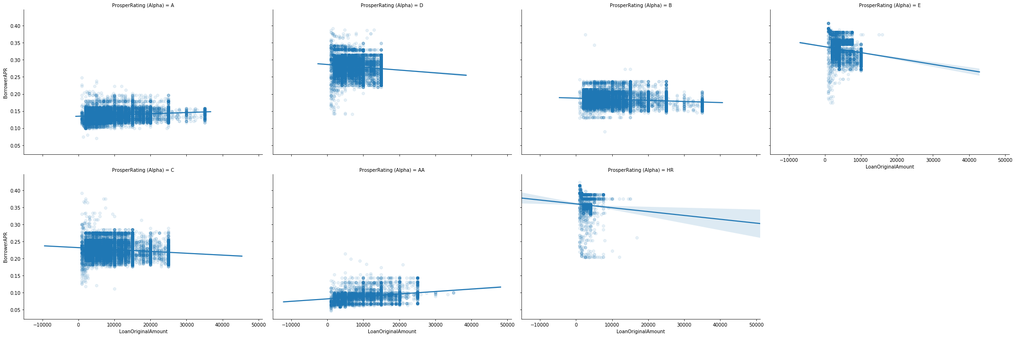

```python
g=sb.FacetGrid(data=loan_data, aspect=1.5, height=5, col='ProsperRating (Alpha)',col_wrap=4)
g.map(sb.regplot, 'LoanOriginalAmount', 'BorrowerAPR', x_jitter=0.03, scatter_kws={'alpha':0.1});
g.add_legend();
```

It looks like the loan amount increases with better prosper rating.Looking at the above Grid closely it looks like people with better prosper rating tend to borrow more because they might be getting a good APR and people with less propser rating tend to borrow less due to high APR